# practical_exercise_2, Methods 3, 2021, autumn semester

## Exercise 2 - comparison of models

For this part, make sure to have `lme4` installed.  
You can install it using `install.packages("lme4")` and load it using `library(lme4)`  
`lmer` is used for multilevel modelling

```r
library(lme4)
mixed.model <- lmer(formula=..., data=...)
example.formula <- formula(dep.variable ~ first.level.variable + (1 | second.level.variable))
```

1. Build four models and do some comparisons
   1. a single level model that models *f0mn* as dependent on *gender*

```r
model1 <- lm(f0mn~gender, data = politeness)
```

```
ii. a two-level model that adds a second level on top of i. where unique intercepts are modelled for each _scenario_
```

```r
model2 <- lmer(f0mn~gender + (1|scenario), data=politeness)
summary(model2)
```

```
## Linear mixed model fit by REML. t-tests use Satterthwaite's method [
## lmerModLmerTest]
## Formula: f0mn ~ gender + (1 | scenario)
##    Data: politeness
##
## REML criterion at convergence: 2144.3
##
## Scaled residuals:
##     Min      1Q  Median      3Q     Max
## -3.2314 -0.6033 -0.1599  0.4893  4.2069
##
## Random effects:
##  Groups   Name        Variance Std.Dev.
##  scenario (Intercept)   91.77   9.579
##  Residual             1478.25  38.448
## Number of obs: 212, groups:  scenario, 7
##
## Fixed effects:
##             Estimate Std. Error       df t value Pr(>|t|)
## (Intercept)  247.786      5.033    9.481   49.23 9.57e-13 ***
## genderM     -115.875      5.338  204.193  -21.71  < 2e-16 ***
## ---
## Signif. codes:  0 '***' 0.001 '**' 0.01 '*' 0.05 '.' 0.1 ' ' 1
##
## Correlation of Fixed Effects:
##         (Intr)
## genderM -0.455
```

```
iii. a two-level model that only has _subject_ as an intercept
```

```r
model3 <- lmer(f0mn ~ gender + (1|subject), data=politeness)
summary(model3)
```

```
## Linear mixed model fit by REML. t-tests use Satterthwaite's method [
## lmerModLmerTest]
## Formula: f0mn ~ gender + (1 | subject)
##    Data: politeness
##
## REML criterion at convergence: 2091.6
##
## Scaled residuals:
##     Min      1Q  Median      3Q     Max
## -3.2200 -0.5402 -0.1385  0.4358  3.8184
##
## Random effects:
##  Groups   Name        Variance Std.Dev.
##  subject  (Intercept)  595.1   24.39
##  Residual             1026.7   32.04
## Number of obs: 212, groups:  subject, 16
##
## Fixed effects:
##             Estimate Std. Error       df t value Pr(>|t|)
## (Intercept)  246.525      8.641   13.988  28.531 8.49e-14 ***
## genderM     -115.181     13.080   14.059  -8.806 4.27e-07 ***
## ---
## Signif. codes:  0 '***' 0.001 '**' 0.01 '*' 0.05 '.' 0.1 ' ' 1
##
## Correlation of Fixed Effects:
##         (Intr)
## genderM -0.661
```

```
iv. a two-level model that models intercepts for both _scenario_ and _subject_
```

```r
model4 <- lmer(f0mn ~ gender + (1|scenario) + (1|subject), data = politeness)
```

```
v. which of the models has the lowest residual standard deviation, also compare the Akaike Information Criterion `AIC`?
```

```r
#We find the residual standard deviation
c(sigma(model4),
  sigma(model3),
  sigma(model2),
  sigma(model1))
```

```
## [1] 30.65803 32.04287 38.44800 39.46268
```

```r
#Model 4 has the lowest residual standard deviation of 30.65.

#We now find the AIC of the models by running an ANOVA
AIC_model1to4 <- anova(model4, model3, model2, model1)
```

```
## refitting model(s) with ML (instead of REML)
```

```r
AIC_model1to4$AIC
```

```
## [1] 2163.971 2112.048 2162.257 2105.176
```

```r
#Model 4 has the lowest AIC score of 2105.2.

#Overall, model 4 has the lowest residual standard deviation and also the lowest AIC score (model4 is the model with the level 2 predictors (1|subject)+(1|scenario)).
```

```
vi. which of the second-level effects explains the most variance?
```

```r
#Since we are examining which of the second-level effects that explains the most variance, we must confine ourselves to model 2 and model 3 and compare these with each other. Otherwise, if model 4 would be included, we would not be able to compare (1|subject) with (1|scenario) and see which of these two second-level effects explain the most variance (since model4 includes both second-level effects (1|subject) and (1|scenario). We want to contrast these two effects and therefore we have to contrast the two models that contain only one of them each.

#We use the function rsq() to ascertain the variance explained by the models. There are three parts of the r.sq() output: the variance explained by the entire model (fixed and random effects), the variance explained by the fixed effects only and the variance explained by the random effects only.

model3_rsq <- rsq(model3)

model2_rsq <- rsq(model2)

model3_rsq
```

```
## $model
## [1] 0.7938981
##
## $fixed
## [1] 0.6804095
##
## $random
## [1] 0.1134886
```

```r
model2_rsq
```

```
## $model
## [1] 0.6989103
##
## $fixed
## [1] 0.6805506
##
## $random
## [1] 0.01835976
```

```r
#We see that for model 3 the level 2 predictor accounts for approximately 11% of the total variance explained (the total variance explained being a combination of the fixed and random effects). In other words, model 3 explains 79% of the total variation of the data, where the fixed effects of model 3 account for approximately 68% of the 79%, which means the random effects of model 3 account for approximately 11% of the variance explained by the model.

#On the other hand, the level 2 predictor for model 2 only accounts for approximately 1.8% of the total variance explained by model 2.

#In other words, the variable "subject" explains more of the variance of the data as a second-level effect than does the variable "scenario".
```

2. Why is our single-level model bad?
   1. create a new data frame that has three variables, *subject*, *gender* and *f0mn*, where *f0mn* is the average of all responses of each subject, i.e. averaging across *attitude* and_scenario_

```r
politeness_newdf <- politeness %>%
  group_by(subject, gender) %>% summarise(mean(f0mn))
colnames(politeness_newdf) <- c("subject", "gender", "f0mn")
```

```
ii. build a single-level model that models _f0mn_ as dependent on _gender_ using this new dataset
```

```r
f0mngender <- lm(f0mn~gender, data=politeness_newdf)

summary(f0mngender)
```

```
##
## Call:
## lm(formula = f0mn ~ gender, data = politeness_newdf)
##
## Residuals:
##     Min      1Q  Median      3Q     Max
## -34.606 -15.493  -8.212  15.702  52.859
##
## Coefficients:
##             Estimate Std. Error t value Pr(>|t|)
## (Intercept)  246.370      8.635  28.530 8.34e-14 ***
## genderM     -115.092     13.055  -8.816 4.35e-07 ***
## ---
## Signif. codes:  0 '***' 0.001 '**' 0.01 '*' 0.05 '.' 0.1 ' ' 1
##
## Residual standard error: 25.91 on 14 degrees of freedom
## Multiple R-squared:  0.8474, Adjusted R-squared:  0.8365
## F-statistic: 77.72 on 1 and 14 DF,  p-value: 4.346e-07
```

[output not shown]

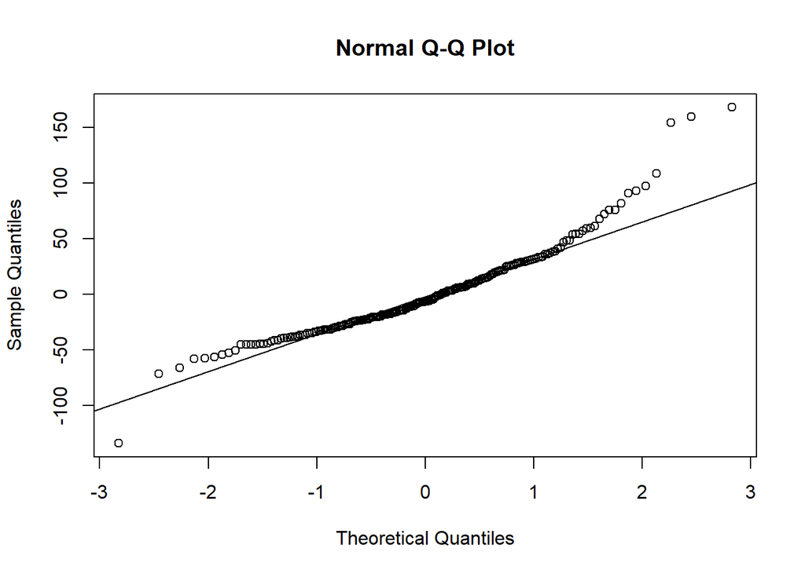

```r
qqnorm(model1$residuals)
qqline(model1$residuals)
```